# Project

Emily Medema

2019-03-06

## Project: Pokemon Dataset

```r
pokemon<-read.csv("pokemon_alopez247.csv")
#plot(pokemon)
#plot(pokemon$Name~pokemon$Type_1)
#plot(pokemon$Name~. , data = pokemon, col = "blueviolet")
#look at all those tasty graphs
summary(pokemon)
```

```
##      Number            Name         Type_1         Type_2
##  Min.   :  1   Abomasnow :  1   Water  :105           :371
##  1st Qu.:181   Abra      :  1   Normal : 93   Flying  : 87
##  Median :361   Absol     :  1   Grass  : 66   Poison  : 31
##  Mean   :361   Accelgor  :  1   Bug    : 63   Ground  : 30
##  3rd Qu.:541   Aegislash :  1   Fire   : 47   Psychic : 27
##  Max.   :721   Aerodactyl:  1   Psychic: 47   Fighting: 19
##                (Other)   :715   (Other):300   (Other) :156
##      Total             HP             Attack          Defense
##  Min.   :180.0   Min.   :  1.00   Min.   :  5.00   Min.   :  5.00
##  1st Qu.:320.0   1st Qu.: 50.00   1st Qu.: 53.00   1st Qu.: 50.00
##  Median :424.0   Median : 65.00   Median : 74.00   Median : 65.00
##  Mean   :417.9   Mean   : 68.38   Mean   : 75.01   Mean   : 70.81
##  3rd Qu.:499.0   3rd Qu.: 80.00   3rd Qu.: 95.00   3rd Qu.: 85.00
##  Max.   :720.0   Max.   :255.00   Max.   :165.00   Max.   :230.00
##
##      Sp_Atk           Sp_Def           Speed          Generation
##  Min.   : 10.00   Min.   : 20.00   Min.   :  5.00   Min.   :1.000
##  1st Qu.: 45.00   1st Qu.: 50.00   1st Qu.: 45.00   1st Qu.:2.000
##  Median : 65.00   Median : 65.00   Median : 65.00   Median :3.000
##  Mean   : 68.74   Mean   : 69.29   Mean   : 65.71   Mean   :3.323
##  3rd Qu.: 90.00   3rd Qu.: 85.00   3rd Qu.: 85.00   3rd Qu.:5.000
##  Max.   :154.00   Max.   :230.00   Max.   :160.00   Max.   :6.000
##
##  isLegendary     Color     hasGender      Pr_Male             Egg_Group_1
##  False:675   Blue   :134   False: 77   Min.   :0.0000   Field       :169
##  True : 46   Brown  :110   True :644   1st Qu.:0.5000   Monster     : 74
##              Green  : 79               Median :0.5000   Water_1     : 74
##              Red    : 75               Mean   :0.5534   Undiscovered: 73
##              Grey   : 69               3rd Qu.:0.5000   Bug         : 66
##              Purple : 65               Max.   :1.0000   Mineral     : 46
##              (Other):189               NA's   :77       (Other)     :219
##      Egg_Group_2  hasMegaEvolution    Height_m        Weight_kg
##            :530   False:675        Min.   : 0.100   Min.   :  0.10
##  Dragon    : 35   True : 46        1st Qu.: 0.610   1st Qu.:  9.40
##  Grass     : 32                    Median : 0.990   Median : 28.00
##  Field     : 31                    Mean   : 1.145   Mean   : 56.77
##  Fairy     : 17                    3rd Qu.: 1.400   3rd Qu.: 61.00
##  Human-Like: 15                    Max.   :14.500   Max.   :950.00
##  (Other)   : 61
##    Catch_Rate               Body_Style
##  Min.   :  3.0   bipedal_tailed  :158
##  1st Qu.: 45.0   quadruped       :135
##  Median : 65.0   bipedal_tailless:109
##  Mean   :100.2   two_wings       : 63
##  3rd Qu.:180.0   head_arms       : 39
##  Max.   :255.0   head_only       : 34
##                  (Other)         :183
```

Let’s get some insight into the data in general. For example, lets look at a graph of the number of pokemon per type.

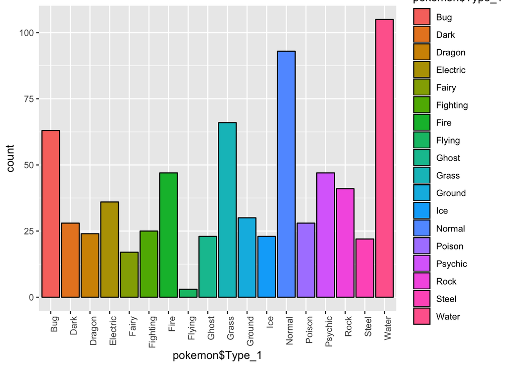

```r
library(ggplot2)
type<-ggplot(pokemon, aes(pokemon$Type_1, fill = pokemon$Type_1)) + geom_histogram(stat="count", color = "black") + theme(axis.text.x = element_text(angle = 90, hjust = 1))
type
```

Before we get too far along, let’s split up the data into training and testing sets

```r
#n <- nrow(pokemon)
#shuffled_df <- pokemon[sample(n), ]
#train_indices <- 1:round(0.6 * n)
#train <- shuffled_df[train_indices, ]
#test_indices <- (round(0.6 * n) + 1):n
#test <- shuffled_df[test_indices, ]
set.seed(1995)
train<-sample(1:nrow(pokemon),432)
poke.test<-pokemon[-train,]
poke.train<-pokemon[train,]
```

Let’s try fitting a linear model with the response variable total and predictors HP, Attack, and Defense.

```r
library(DAAG)
linmod <- lm(poke.train$Total~poke.train$HP+poke.train$Attack+poke.train$Defense)
summary(linmod)
```

```
##
## Call:
## lm(formula = poke.train$Total ~ poke.train$HP + poke.train$Attack +
##     poke.train$Defense)
##
## Residuals:
##      Min       1Q   Median       3Q      Max
## -142.490  -36.208   -3.329   38.538  175.198
##
## Coefficients:
##                    Estimate Std. Error t value Pr(>|t|)
## (Intercept)         95.0651    10.2131   9.308   <2e-16 ***
## poke.train$HP        1.8062     0.1146  15.757   <2e-16 ***
## poke.train$Attack    1.4849     0.1168  12.711   <2e-16 ***
## poke.train$Defense   1.2479     0.1051  11.873   <2e-16 ***
## ---
## Signif. codes:  0 '***' 0.001 '**' 0.01 '*' 0.05 '.' 0.1 ' ' 1
##
## Residual standard error: 57.46 on 428 degrees of freedom
## Multiple R-squared:  0.7209, Adjusted R-squared:  0.719
## F-statistic: 368.5 on 3 and 428 DF,  p-value: < 2.2e-16
```

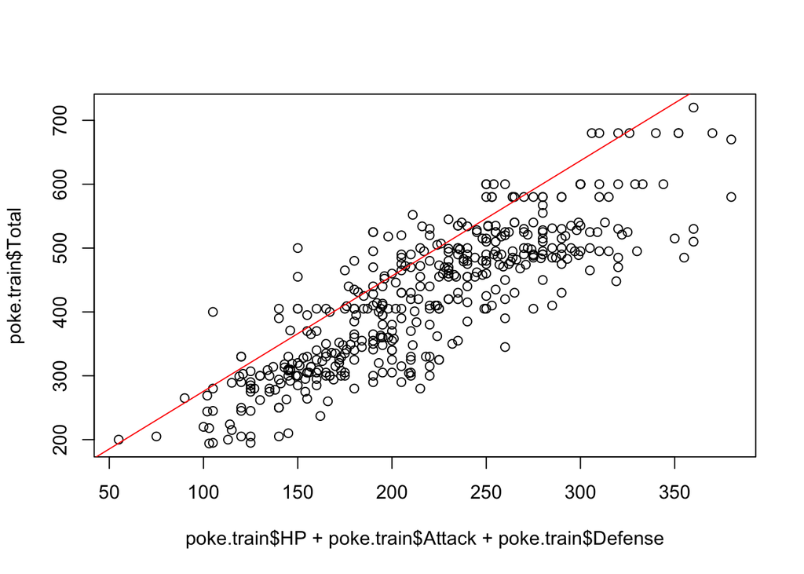

```r
#plot(linmod)
plot(poke.train$HP+poke.train$Attack+poke.train$Defense, poke.train$Total)
abline(linmod, h = 0.5, col = "red")
```

```r
#mmmm tasty sig values
predicted<-predict(linmod, newdata=poke.test)
mean(linmod$residuals^2)
```

```
## [1] 3271.247
```

```r
mean((poke.test$Total-predicted)^2)
```

```
## [1] 20635.98
```

First attempt at Clustering

```r
eucdist<-dist(pokemon, method="euclidean")
```

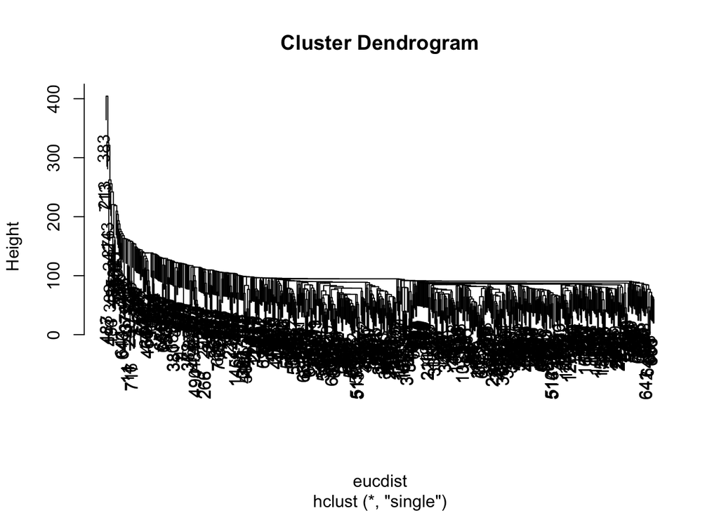

```r
clusPokemon<-hclust(eucdist, method = "single")
plot(clusPokemon)
```

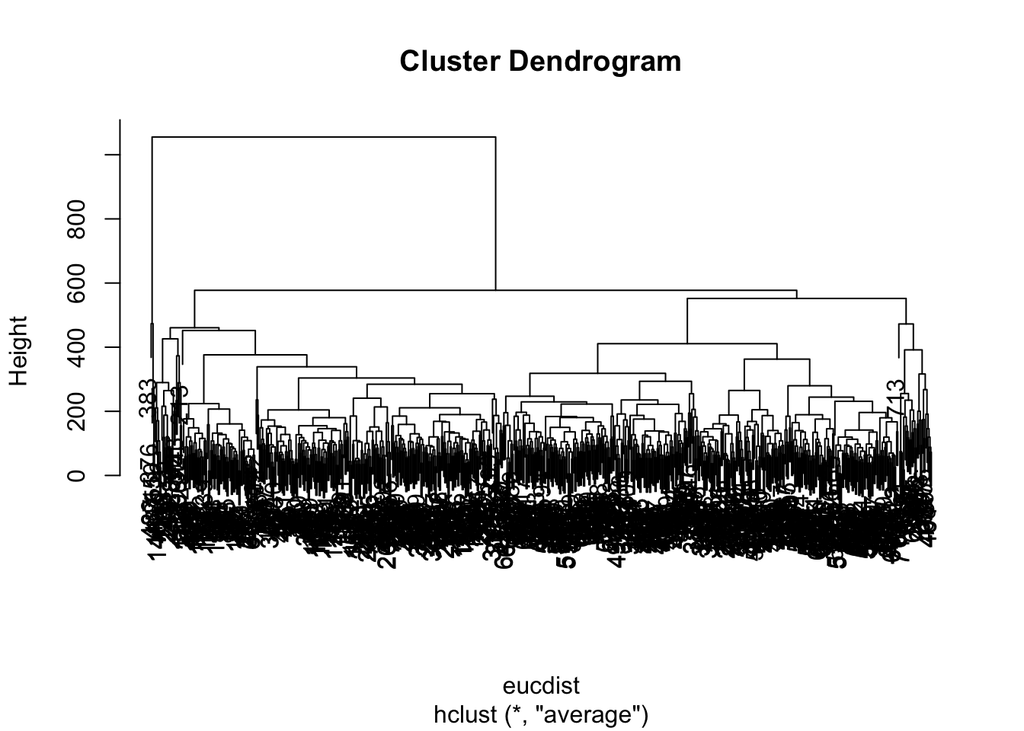

```r
clusPokemonAvg<-hclust(eucdist, method = "average")
plot(clusPokemonAvg)
```

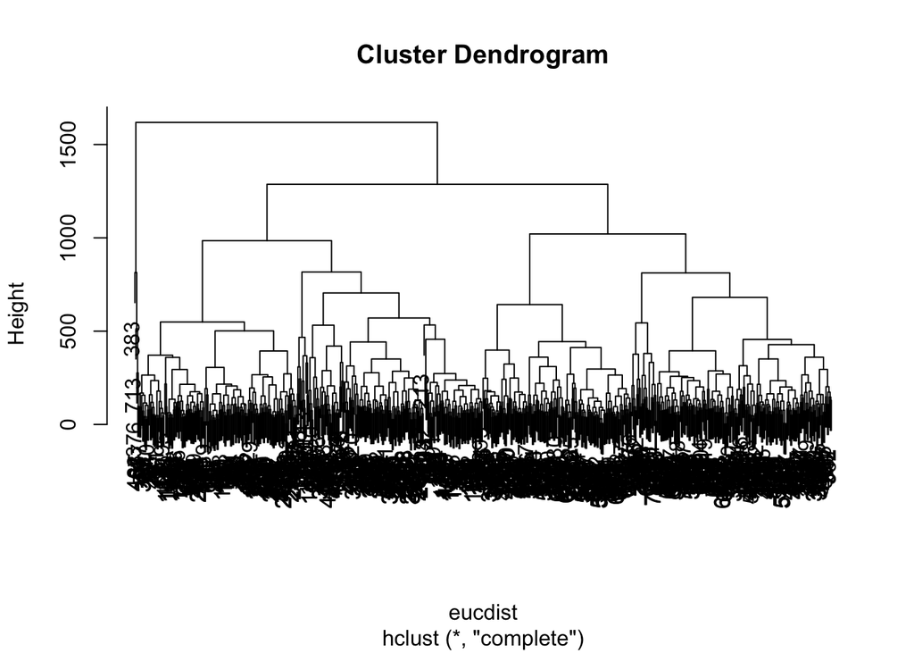

```r
clusComplete<-hclust(eucdist, method = "complete")
plot(clusComplete)
```

@Barrett

See what a regression tree looks like using total as the predictor and hp, attack, defense, sp_atk, sp_def, and speed as predictors.

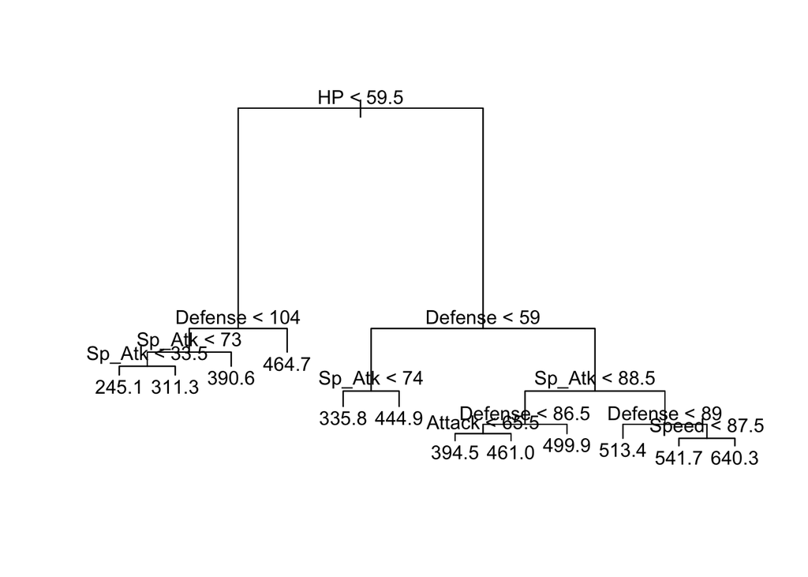

```r
library(tree)
poke<-data.frame(pokemon)
attach(poke)
pocl<-tree(Total~HP+Attack+Defense+Sp_Atk+Sp_Def+Speed,data=poke)
plot(pocl)
text(pocl)
```

Now let’s try pruning it back

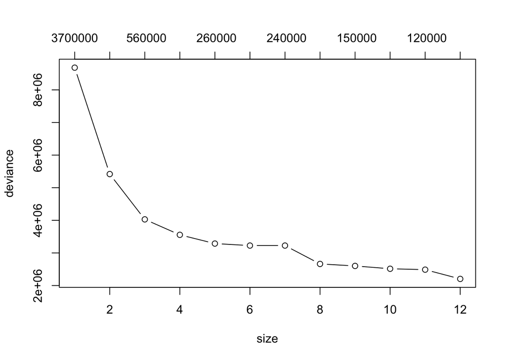

```r
cv.pocl<-cv.tree(pocl, FUN=prune.tree)
plot(cv.pocl,type="b")
```

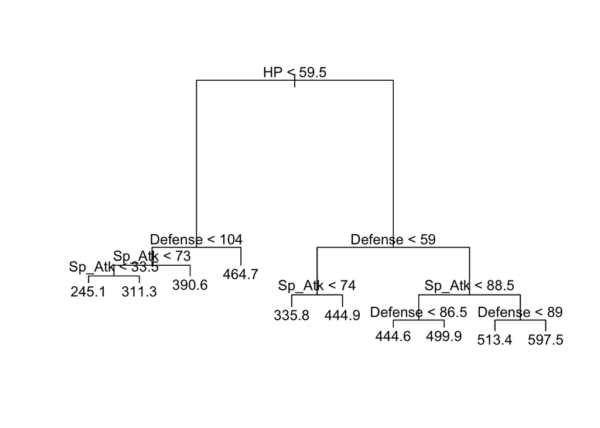

```r
p.pocl<-prune.tree(pocl,best=10)
plot(p.pocl)
text(p.pocl)
```

```r
summary(p.pocl)
```

```
##
## Regression tree:
## snip.tree(tree = pocl, nodes = c(28L, 31L))
## Variables actually used in tree construction:
## [1] "HP"      "Defense" "Sp_Atk"
## Number of terminal nodes:  10
## Residual mean deviance:  2592 = 1843000 / 711
## Distribution of residuals:
##      Min.   1st Qu.    Median      Mean   3rd Qu.      Max.
## -164.6000  -31.2800    0.0625    0.0000   28.7200  209.4000
```

Looks like pruning was unnecessary since the lowest MSE is with 12 nodes…

How about with bagging…

```r
library(randomForest)
set.seed(1995)
pokebag<-randomForest(Total~HP+Attack+Defense+Sp_Atk+Sp_Def+Speed,data=poke,mtry=6,importance=FALSE)
pokebag
```

```
##
## Call:
##  randomForest(formula = Total ~ HP + Attack + Defense + Sp_Atk +      Sp_Def + Speed, data = poke, mtry = 6, importance = FALSE)
##                Type of random forest: regression
##                      Number of trees: 500
## No. of variables tried at each split: 6
##
##           Mean of squared residuals: 520.2918
##                     % Var explained: 95.67
```

Random forest where m=3

```r
pokeRF<-randomForest(Total~HP+Attack+Defense+Sp_Atk+Sp_Def+Speed,data=poke,mtry=3,importance=TRUE)
pokeRF
```

```
##
## Call:
##  randomForest(formula = Total ~ HP + Attack + Defense + Sp_Atk +      Sp_Def + Speed, data = poke, mtry = 3, importance = TRUE)
##                Type of random forest: regression
##                      Number of trees: 500
## No. of variables tried at each split: 3
##
##           Mean of squared residuals: 500.405
##                     % Var explained: 95.83
```

Now, let’s try to predict if a pokemon is legendary. I would assume that pokemon with a high total are legendary and after taking a peek at the data, it looks like most legendary pokemon do not have a gender. Let’s see if this holds true in general.

```r
#https://www.kaggle.com/excaliburzero/predicting-legendary-pokemon
maxTotal<-order(poke.train$Total, decreasing = TRUE)
head(poke.train[maxTotal,])
```

```
##     Number     Name  Type_1 Type_2 Total  HP Attack Defense Sp_Atk Sp_Def
## 493    493   Arceus  Normal          720 120    120     120    120    120
## 484    484   Palkia   Water Dragon   680  90    120     100    150    120
## 717    717  Yveltal    Dark Flying   680 126    131      95    131     98
## 643    643 Reshiram  Dragon   Fire   680 100    120     100    150    120
## 483    483   Dialga   Steel Dragon   680 100    120     120    150    100
## 249    249    Lugia Psychic Flying   680 106     90     130     90    154
##     Speed Generation isLegendary  Color hasGender Pr_Male  Egg_Group_1
## 493   120          4        True   Grey     False      NA Undiscovered
## 484   100          4        True Purple     False      NA Undiscovered
## 717    99          6        True    Red     False      NA Undiscovered
## 643    90          5        True  White     False      NA Undiscovered
## 483    90          4        True  White     False      NA Undiscovered
## 249   110          2        True  White     False      NA Undiscovered
##     Egg_Group_2 hasMegaEvolution Height_m Weight_kg Catch_Rate
## 493                        False     3.20       320          3
## 484                        False     4.19       336          3
## 717                        False     5.79       203         45
## 643                        False     3.20       330          3
## 483                        False     5.41       683          3
## 249                        False     5.21       216          3
##         Body_Style
## 493      quadruped
## 484 bipedal_tailed
## 717      two_wings
## 643      two_wings
## 483      quadruped
## 249      two_wings
```

This looks like if we have a high total the pokemon is most likely legendary. Let’s graph it to see if it holds true

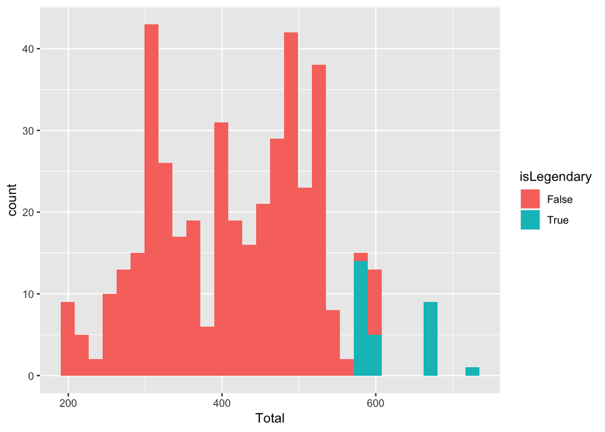

```r
library(ggplot2)
plot<-ggplot(poke.train, aes(x =Total, fill = isLegendary)) + geom_histogram()
plot
```

Now let’s look at gender correlation

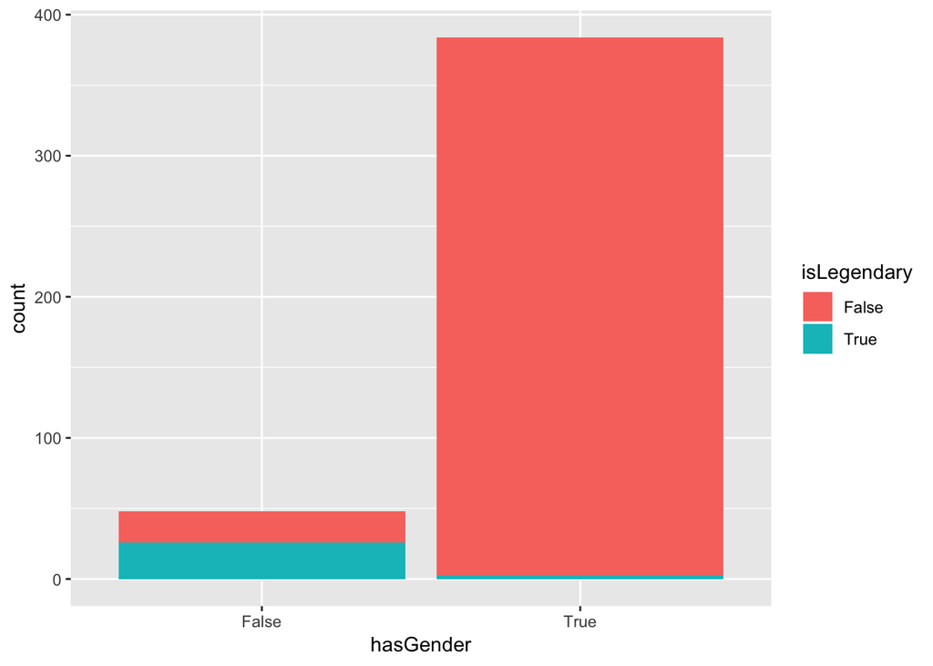

```r
poke.train$hasGender<-factor(poke.train$hasGender)
plot2<-ggplot(poke.train, aes(x =hasGender, fill = isLegendary)) + geom_bar()
plot2
```

This plot shows that most legendary pokemon do not have a gender.

Kmeans

```r
library(mclust)
library(cluster)
distPoke<-daisy(poke.train)
summary(distPoke)
```

```
## 93096 dissimilarities, summarized :
##    Min. 1st Qu.  Median    Mean 3rd Qu.    Max.
## 0.05484 0.34190 0.38898 0.39268 0.43884 0.72736
## Metric :  mixed ;  Types = I, N, N, N, I, I, I, I, I, I, I, I, N, N, N, I, N, N, N, I, I, I, N
## Number of objects : 432
```

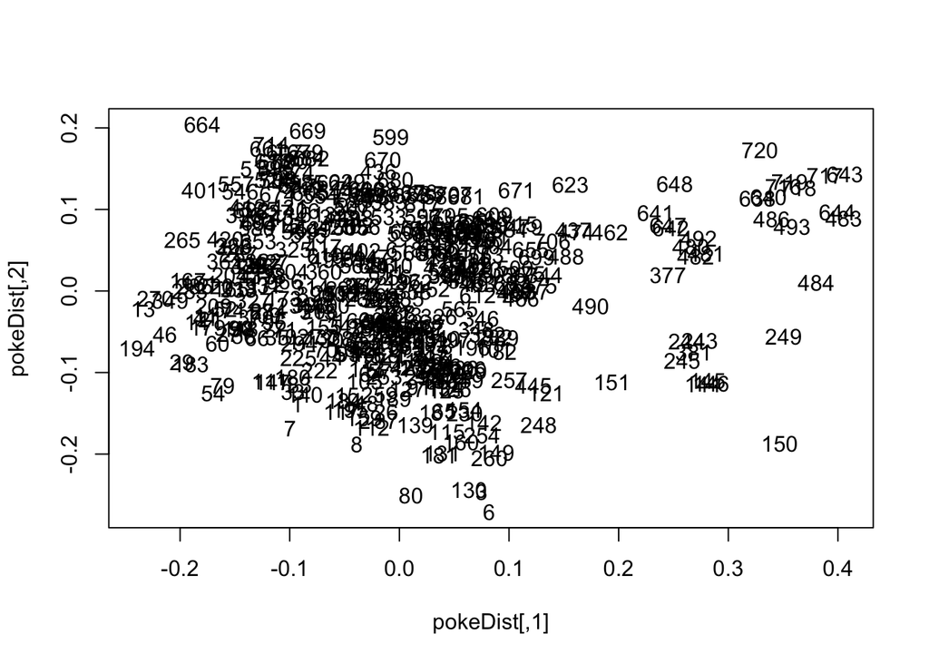

```r
pokeDist<-cmdscale(distPoke)
plot(pokeDist, type = "n")
text(pokeDist, rownames(pokeDist))
```

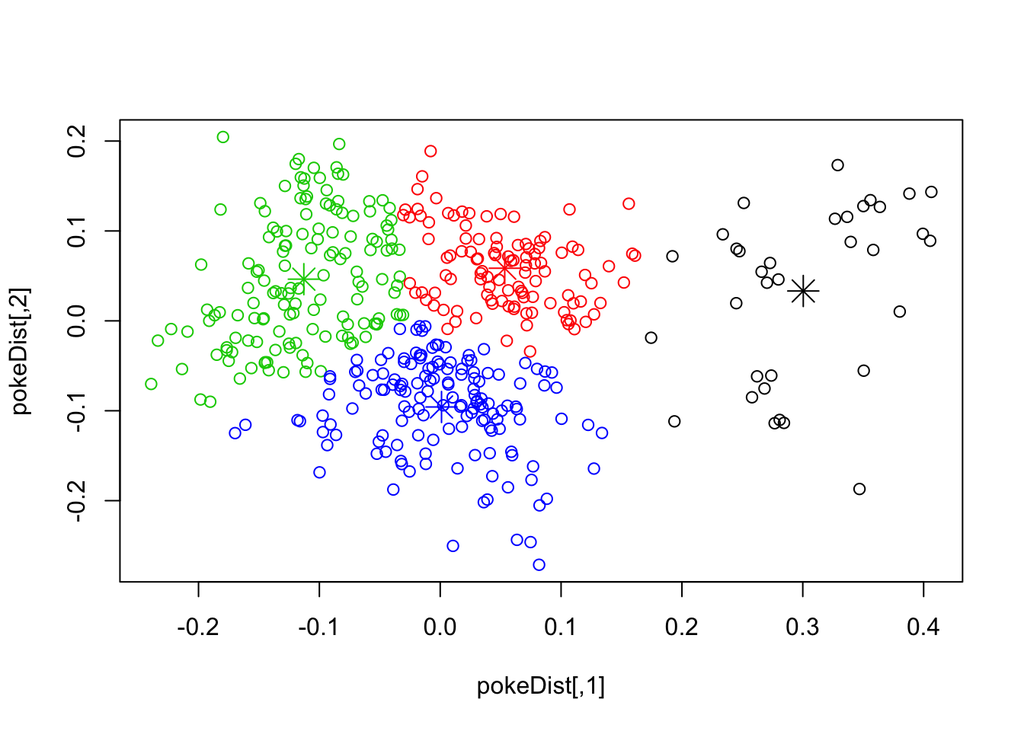

```r
set.seed(413)
#kAnimals<-kmeans(dAnimals, 3)
#plot(dAnimals, col = kAnimals$cluster)
#points(kAnimals$centers, col = 1:3, pch=8, cex=2)

kPoke2<-kmeans(pokeDist, 4, nstart=16)
plot(pokeDist, col = kPoke2$cluster)
points(kPoke2$centers, col = 1:4, pch=8, cex=2)
```

```r
#kAnimals$cluster
table(rownames(poke.train), kPoke2$cluster)
```

```
##
##       1 2 3 4
##   1   0 0 0 1
##   100 0 0 1 0
##   101 0 0 0 1
##   102 0 0 1 0
##   105 0 0 0 1
##   107 0 0 0 1
##   109 0 0 1 0
##   11  0 0 1 0
##   110 0 0 0 1
##   111 0 0 0 1
##   112 0 0 0 1
##   113 0 0 0 1
##   115 0 0 0 1
```

[output cut: 419 more lines]

KNN classification

```r
library(class)
knnrun<-knn.cv(pokeDist, cl = poke.train$isLegendary, k = 5, prob = TRUE)
table(poke.train$isLegendary, knnrun)
```

```
##        knnrun
##         False True
##   False   400    3
##   True      1   28
```

Let’s try analyzing via LDA

```r
library(MASS)
library(MLmetrics)
poke.train$hasGender<-factor(poke.train$hasGender)
poke.train$isLegendary<-factor(poke.train$isLegendary)
pokelda<-lda(poke.train$isLegendary~poke.train$hasGender+poke.train$Total)
table(poke.train$isLegendary, predict(pokelda)$class)
```

```
##
##         False True
##   False   381   22
##   True      3   26
```

```r
Sensitivity(poke.train$isLegendary, predict(pokelda)$class)
```

```
## [1] 0.9454094
```

```r
Recall(poke.train$isLegendary, predict(pokelda)$class) #same as sensitivity
```

```
## [1] 0.9454094
```

```r
Precision(poke.train$isLegendary, predict(pokelda)$class)
```

```
## [1] 0.9921875
```

```r
Specificity(poke.train$isLegendary, predict(pokelda)$class)
```

```
## [1] 0.8965517
```

```r
F1_Score(poke.train$isLegendary, predict(pokelda)$class)
```

```
## [1] 0.9682338
```

Now let’s try qda

```r
pokeqda<-qda(poke.train$isLegendary~poke.train$hasGender+poke.train$Total)
table(poke.train$isLegendary, predict(pokeqda)$class)
```

```
##
##         False True
##   False   390   13
##   True      3   26
```

```r
Sensitivity(poke.train$isLegendary, predict(pokelda)$class)
```

```
## [1] 0.9454094
```

```r
Recall(poke.train$isLegendary, predict(pokeqda)$class) #same as sensitivity
```

```
## [1] 0.9677419
```

```r
Precision(poke.train$isLegendary, predict(pokeqda)$class)
```

```
## [1] 0.9923664
```

```r
Specificity(poke.train$isLegendary, predict(pokeqda)$class)
```

```
## [1] 0.8965517
```

```r
F1_Score(poke.train$isLegendary, predict(pokeqda)$class)
```

```
## [1] 0.9798995
```

Now lets try logistic regression

```r
simlog<-glm(factor(poke.train$isLegendary)~poke.train$hasGender+poke.train$Total, family = "binomial")
table(predict(simlog, type = "response")>0.5, poke.train$isLegendary)
```

```
##
##         False True
##   FALSE   399    3
##   TRUE      4   26
```

I’m going to see how many legendary pokemon there are per generation and per type. As a refresher here is the number of pokemon per type in this dataset

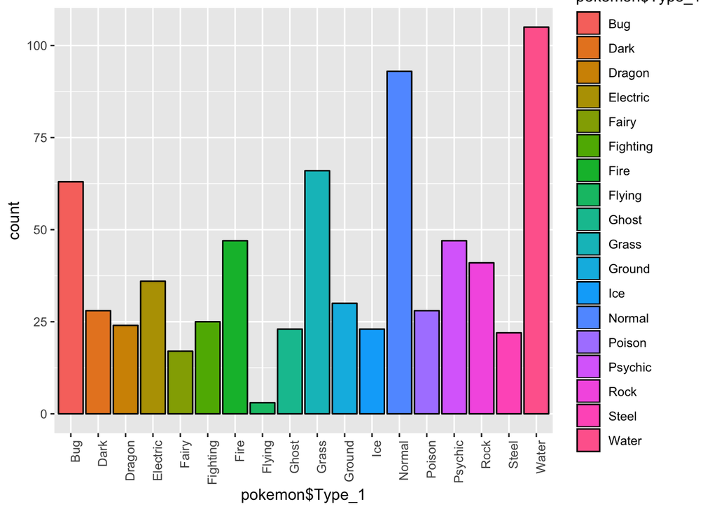

```r
library(ggplot2)
type<-ggplot(pokemon, aes(pokemon$Type_1, fill = pokemon$Type_1)) + geom_histogram(stat="count", color = "black") + theme(axis.text.x = element_text(angle = 90, hjust = 1))
type
```

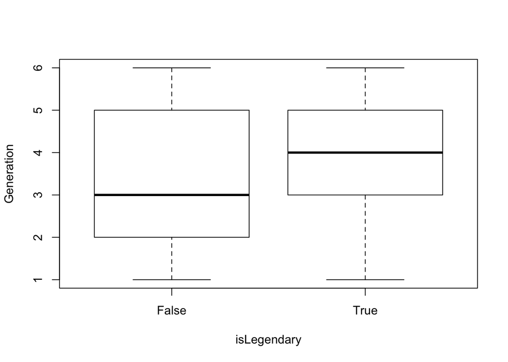

```r
library(wesanderson)
#https://www.kaggle.com/excaliburzero/predicting-legendary-pokemon
poke<-data.frame(pokemon)
pokeLegend<-poke[which(isLegendary=='True'),]
plot(Generation~isLegendary)
```

```r
TheLegends<-as.data.frame(table(pokeLegend$Generation))
colnames(TheLegends)<-c("Generation", "Legends")
TheLegends
```

```
##   Generation Legends
## 1          1       4
## 2          2       5
## 3          3      10
## 4          4      11
## 5          5      10
## 6          6       6
```

```r
summary(TheLegends)
```

```
##  Generation    Legends
##  1:1        Min.   : 4.000
##  2:1        1st Qu.: 5.250
##  3:1        Median : 8.000
##  4:1        Mean   : 7.667
##  5:1        3rd Qu.:10.000
##  6:1        Max.   :11.000
```

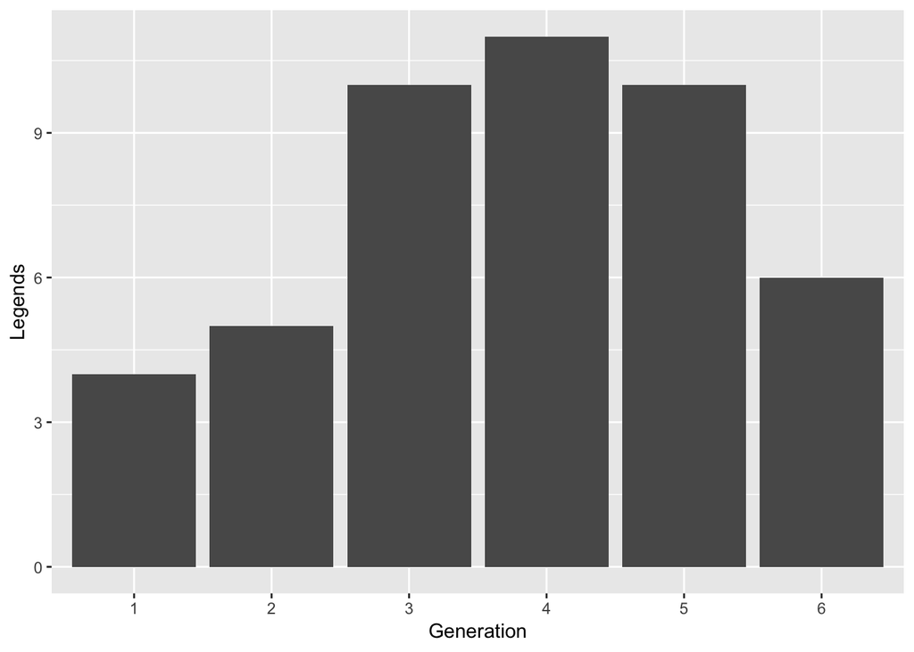

```r
plot<-ggplot(TheLegends, aes(Generation, Legends))+geom_bar(stat="identity")
plot
```

```r
#color=scale_fill_manual(values=wes_palette("FantasticFox1"))
TheMan<-as.data.frame(table(pokeLegend$Type_1))
colnames(TheMan)<-c("Type 1", "Legends")
TheMan
```

```
##      Type 1 Legends
## 1       Bug       0
## 2      Dark       2
## 3    Dragon       7
## 4  Electric       3
## 5     Fairy       1
## 6  Fighting       0
## 7      Fire       5
## 8    Flying       1
## 9     Ghost       1
## 10    Grass       2
## 11   Ground       2
## 12      Ice       2
## 13   Normal       2
## 14   Poison       0
## 15  Psychic       8
## 16     Rock       3
## 17    Steel       4
## 18    Water       3
```

```r
summary(TheMan)
```

```
##       Type 1      Legends
##  Bug     : 1   Min.   :0.000
##  Dark    : 1   1st Qu.:1.000
##  Dragon  : 1   Median :2.000
##  Electric: 1   Mean   :2.556
##  Fairy   : 1   3rd Qu.:3.000
##  Fighting: 1   Max.   :8.000
##  (Other) :12
```

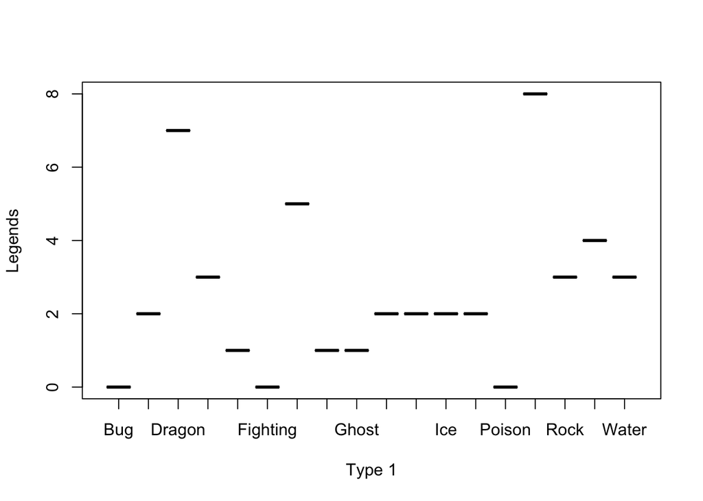

```r
plot(TheMan)
```

```r
maxTotalL<-order(TheMan$Legends, decreasing = TRUE)
head(TheMan[maxTotalL,])
```

```
##      Type 1 Legends
## 15  Psychic       8
## 3    Dragon       7
## 7      Fire       5
## 17    Steel       4
## 4  Electric       3
## 16     Rock       3
```

```r
#Of Type 2
TheMyth<-as.data.frame(table(pokeLegend$Type_2))
colnames(TheMyth)<-c("Type 2", "Legends")
TheMyth
```

```
##      Type 2 Legends
## 1                19
## 2       Bug       0
## 3      Dark       0
## 4    Dragon       3
## 5  Electric       1
## 6     Fairy       1
## 7  Fighting       3
## 8      Fire       2
## 9    Flying       9
## 10    Ghost       1
## 11    Grass       0
## 12   Ground       1
## 13      Ice       1
## 14   Normal       0
## 15   Poison       0
## 16  Psychic       3
## 17     Rock       0
## 18    Steel       1
## 19    Water       1
```

```r
summary(TheMyth)
```

```
##       Type 2      Legends
##          : 1   Min.   : 0.000
##  Bug     : 1   1st Qu.: 0.000
##  Dark    : 1   Median : 1.000
##  Dragon  : 1   Mean   : 2.421
##  Electric: 1   3rd Qu.: 2.500
##  Fairy   : 1   Max.   :19.000
##  (Other) :13
```

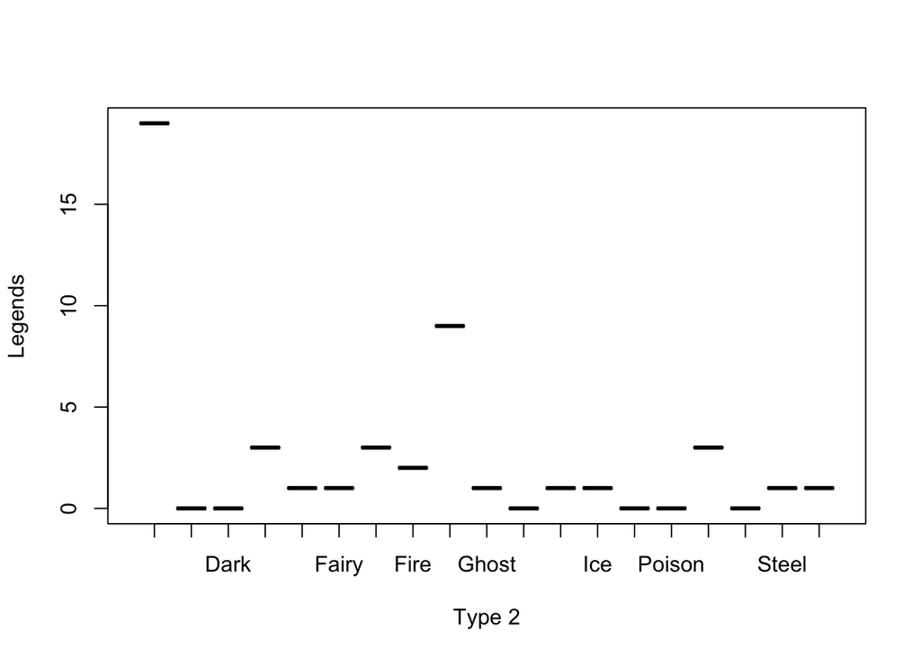

```r
plot(TheMyth)
```

```r
maxTotalL2<-order(TheMyth$Legends, decreasing = TRUE)
head(TheMyth[maxTotalL2,])
```

```
##      Type 2 Legends
## 1                19
## 9    Flying       9
## 4    Dragon       3
## 7  Fighting       3
## 16  Psychic       3
## 8      Fire       2
```

Thanks to @Barret we can now subset the data

```r
poke<-data.frame(pokemon)
poke1<-poke[which(hasGender=='True'),]
attach(poke)
head(poke1)
```

```
##   Number       Name Type_1 Type_2 Total HP Attack Defense Sp_Atk Sp_Def
## 1      1  Bulbasaur  Grass Poison   318 45     49      49     65     65
## 2      2    Ivysaur  Grass Poison   405 60     62      63     80     80
## 3      3   Venusaur  Grass Poison   525 80     82      83    100    100
## 4      4 Charmander   Fire          309 39     52      43     60     50
## 5      5 Charmeleon   Fire          405 58     64      58     80     65
## 6      6  Charizard   Fire Flying   534 78     84      78    109     85
##   Speed Generation isLegendary Color hasGender Pr_Male Egg_Group_1
## 1    45          1       False Green      True   0.875     Monster
## 2    60          1       False Green      True   0.875     Monster
## 3    80          1       False Green      True   0.875     Monster
## 4    65          1       False   Red      True   0.875     Monster
## 5    80          1       False   Red      True   0.875     Monster
## 6   100          1       False   Red      True   0.875     Monster
##   Egg_Group_2 hasMegaEvolution Height_m Weight_kg Catch_Rate
## 1       Grass            False     0.71       6.9         45
## 2       Grass            False     0.99      13.0         45
## 3       Grass             True     2.01     100.0         45
## 4      Dragon            False     0.61       8.5         45
## 5      Dragon            False     1.09      19.0         45
## 6      Dragon             True     1.70      90.5         45
##       Body_Style
## 1      quadruped
## 2      quadruped
## 3      quadruped
## 4 bipedal_tailed
## 5 bipedal_tailed
## 6 bipedal_tailed
```

Let’s see if there is a relationship between score and gender

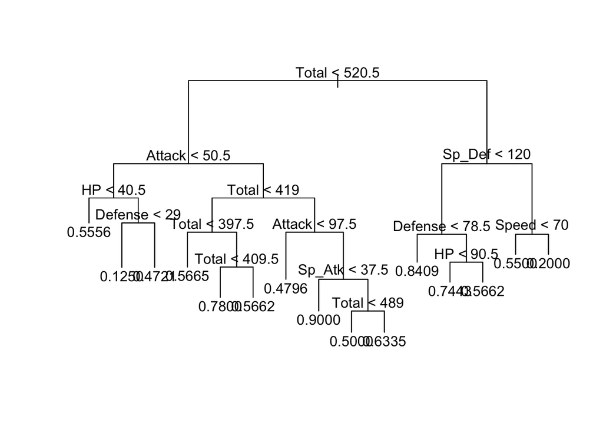

```r
set.seed(983457)
pokeG<-tree(Pr_Male~HP+Attack+Defense+Sp_Atk+Sp_Def+Speed + Total,data=poke1)
plot(pokeG)
text(pokeG, pretty=0)
```

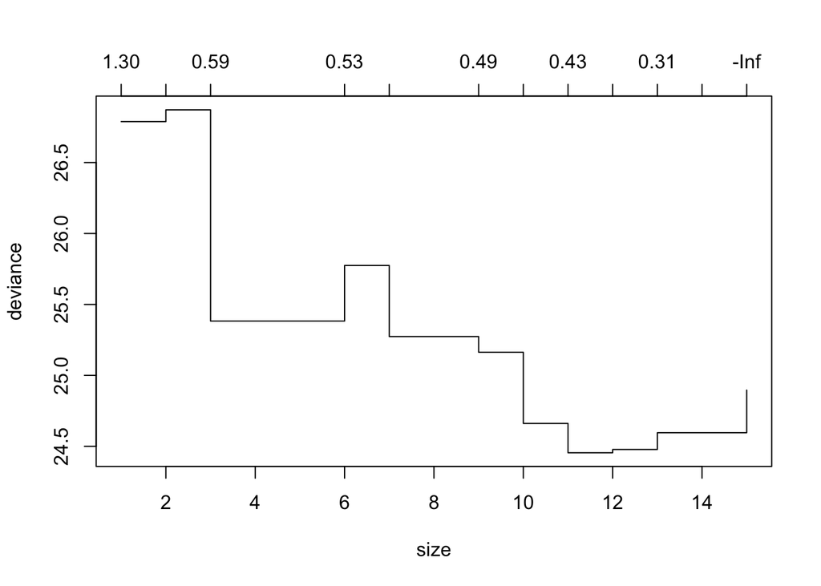

```r
cv.pokeG<-cv.tree(pokeG, FUN=prune.tree)
plot(cv.pokeG)
```

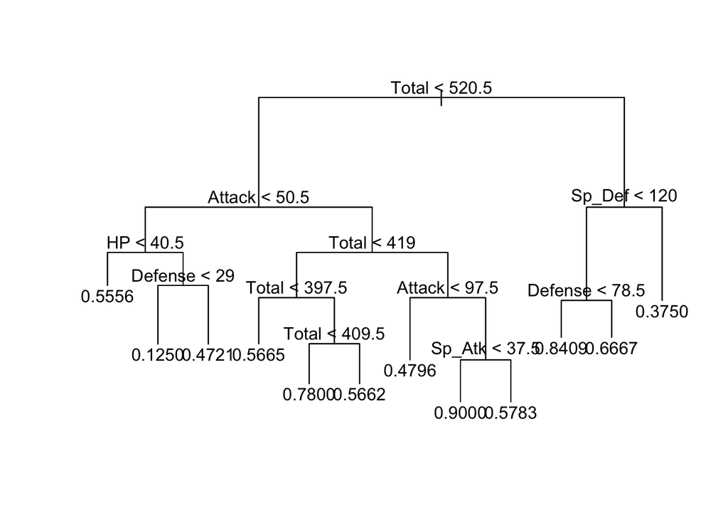

```r
prunePokeG<-prune.tree(pokeG, best=12)
plot(prunePokeG)
text(prunePokeG, pretty=0)
```